# MarineGEO Global Seagrass Survey Preliminary Results

Jon Lefcheck & Jaxine Wolfe

27 July, 2020

The following is a preliminary report of the 2019-2020 MarineGEO Global Seagrass Survey. You can read more about the survey’s goals and methods here: https://marinegeo.github.io/projects/seagrass-food-webs/.

The data are currently stored in an invite-only Dropbox for all participants. Please contact MarineGEO if you have not yet received an invitation to the Dropbox!

As more data are being uploaded all the time to our [MarineGEO Data Portal](https://marinegeo.shinyapps.io/data_portal/), this script may produce different results, depending on whether new data have been added since the last run.

### Metadata Summary

First, let’s see the locations of places where participants have been working, and have already submitted data:

[interactive chart not shown]

As of 27 July 2020, 20 sites on six continents have contributed data to the database–fantastic!

Now, let’s see which variables were measured at which sites:

| Site | Seagrass Density | Seagrass Shoots | Seagrass Biomass | Seagrass Macroalgae | Seagrass Epifauna | Fish Seines | Fish Visual census | Environment Water quality | Environment Organic matter | Process Squidpops |
| --- | --- | --- | --- | --- | --- | --- | --- | --- | --- | --- |
| AUS-PRB | X | X | X | X | X | X |  |  |  |  |
| BEL-CBC | X |  |  |  |  |  |  |  | X |  |
| CAN-BCC | X | X | X | X | X |  | X |  | X |  |
| FIN-GOF | X | X |  | X | X | X |  |  |  |  |
| KOR-DDB | X | X |  | X |  | X |  | X | X | X |
| MDG-RGN | X |  |  |  | X | X |  |  |  |  |
| MDV-OIL | X | X | X | X | X |  | X |  |  |  |
| MEX-ENS | X | X | X | X |  | X | X | X | X |  |
| MEX-PUM | X |  | X | X | X | X |  |  |  |  |
| NOR-ROV | X | X | X | X |  | X | X | X |  |  |
| PAN-BDT | X | X |  | X | X |  | X |  |  |  |
| PHL-PBT | X |  | X | X |  |  |  |  |  |  |
| POR-MAD | X |  |  | X | X |  |  |  |  |  |
| USA-AKA | X | X |  | X |  | X | X | X |  |  |
| USA-IRL | X | X | X | X | X | X | X |  | X |  |
| USA-MDA | X | X |  | X |  | X | X | X |  |  |
| USA-TXS | X | X |  | X |  |  |  | X |  | X |
| USA-VAS | X | X |  | X |  |  |  | X |  |  |
| USA-WAR | X | X | X | X |  | X |  | X |  |  |
| VEN-LCO | X |  | X | X |  | X | X |  |  | X |

### Data Summary

#### Seagrass Characteristics

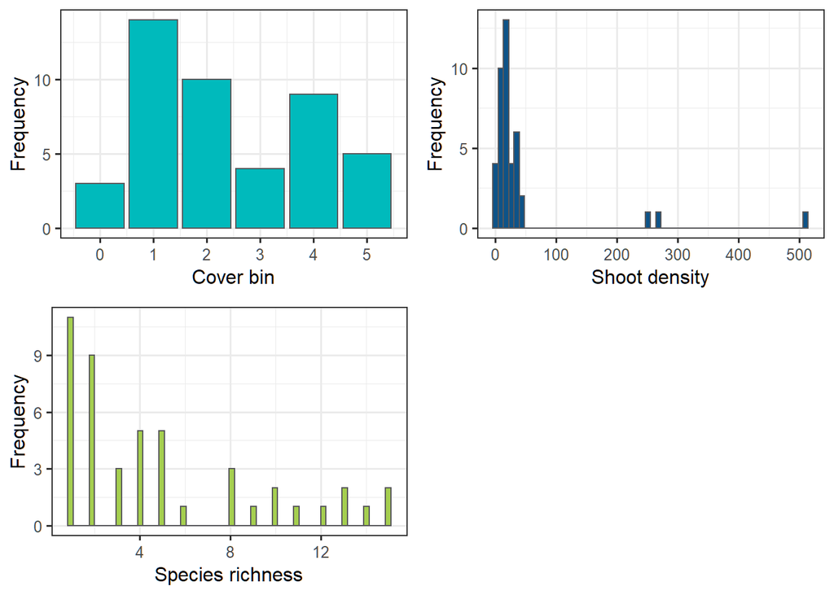

The median cover bin was 2, suggesting reasonably low cover at the plot-level in most locations, but ranged from 0-5, suggesting no to complete cover in some plots.

The median shoot density was 16.58 shoots m<sup>-2</sup>, although ranged as high a 513 shoots m<sup>-2</sup> in Texas, USA.

Participants found between 0-15 species in each plot, ranging from bare sediment, to at least 9 sepecies of seagrasses, to various macroalgae, to corals, sponges, and tunicates.

### Epifaunal characteristics

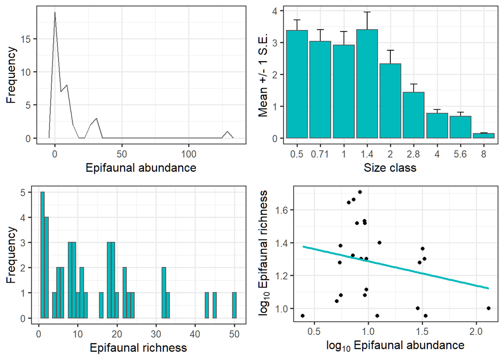

A median of 4.6 epifaunal individuals per plot were obtained, and were predominantly small amphipods and isopods, shrimps, crabs, and gastropods, with a few polychaete and sipunculid worms.

The individuals were predominantly small, falling into the 0.5-1.4 mm size classes.

Median epifaunal richness was 11 species, and ranged from 0 to a maximum of 50 in the Indian River Lagoon, Florida, USA.

Epifaunal abundance and epifaunal richness were weakly negatively correlated (*r* = -0.23) but not significantly so (*P* = 0.28).

### Fish characteristics

We conducted two kinds of fish surveys: seines and visual census.

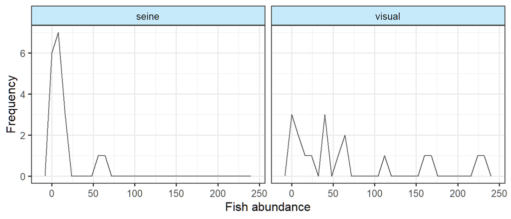

We obtained a median of 7 individuals per seine, and 42 individuals per visual census, with a maximum of 66 fish in a seine and 232 in the visual census.

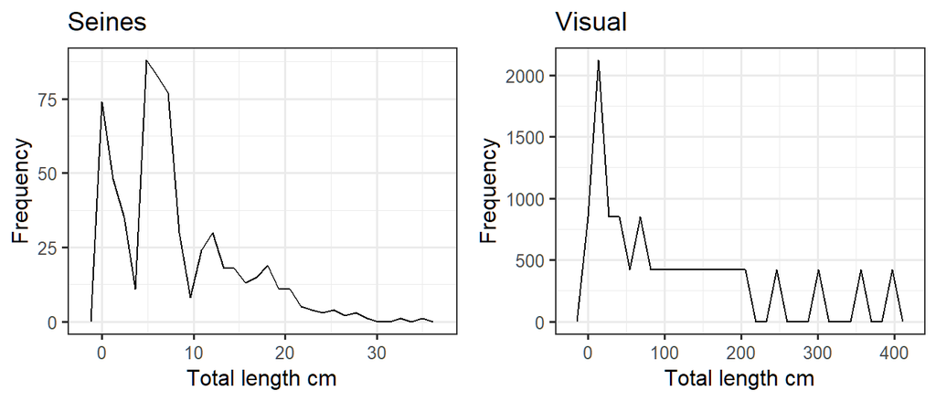

Median fish size was 5.8 cm in the seines, and 81 cm in the visual census.

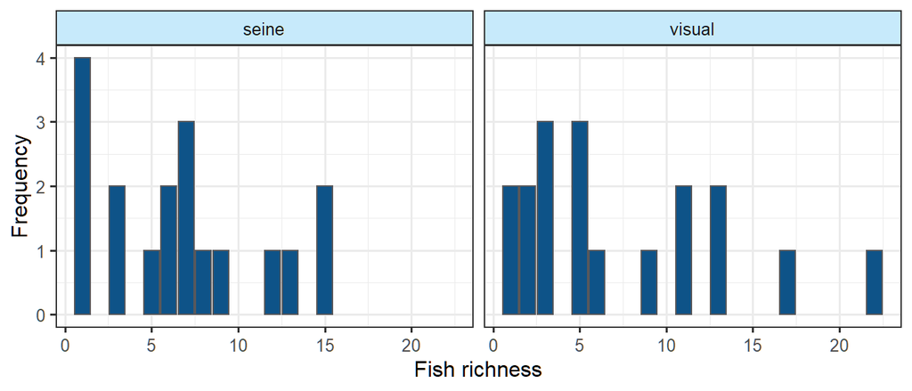

Median fish richness was 7 for the seine and 5 for the visual census, with a maximum of 15 species in the seines in Texas, USA and 22 species in the visual survey in Madagascar.

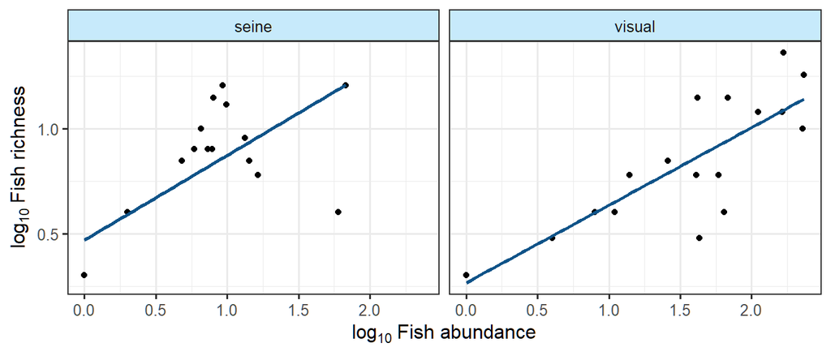

Fish abundance and fish richness were positively but non-significantly correlated for seines (*r* = 0.47, *P* = 0.08), and highly significantly correlated for the visual census (*r* = 0.84, *P* < 0.001).